# Finance & Supply Chain — Profitability and Fulfillment Analysis

Sai

June 24, 2026

## Overview

This report analyzes ~9,000 order-line records from a retail supply-chain dataset (DataCo-style order/shipment data), covering department, profitability, and on-time delivery performance. It’s the R/dplyr companion to an Excel workbook covering the same dataset — the department grouping and risk-flag logic below are direct translations of that workbook’s `VLOOKUP` + nested-`IF` helper columns, included here specifically because this project (unlike the sports/gaming ones) is meant to read as ordinary day-to-day business analytics, not a hobby dataset.

```r
fin <- read.csv("/tmp/clean/finance_clean.csv", stringsAsFactors = FALSE)
glimpse(fin)
```

```
## Rows: 9,000
## Columns: 25
## $ OrderID               <int> 50079, 50082, 50085, 50089, 50095, 50095, 50096,…
## $ OrderItemID           <int> 125204, 125208, 125215, 125226, 125240, 125238, …
## $ OrderDate             <chr> "2017-01-01 00:33:00", "2017-01-01 01:36:00", "2…
## $ PaymentType           <chr> "DEBIT", "PAYMENT", "TRANSFER", "TRANSFER", "PAY…
## $ CustomerSegment       <chr> "Home Office", "Corporate", "Home Office", "Cons…
## $ Market                <chr> "Europe", "Africa", "Africa", "Pacific Asia", "E…
## $ OrderRegion           <chr> "Eastern Europe", "West Africa", "Southern Afric…
## $ OrderCountry          <chr> "Rusia", "Ghana", "SudAfrica", "Turquía", "Rusia…
## $ Department            <chr> "Golf", "Apparel", "Fan Shop", "Apparel", "Appar…
## $ Category              <chr> "Shop By Sport", "Men's Footwear", "Fishing", "C…
## $ ProductName           <chr> "Under Armour Girls' Toddler Spine Surge Runni",…
## $ Quantity              <int> 1, 1, 1, 3, 1, 5, 4, 2, 1, 1, 1, 5, 1, 1, 1, 5, …
## $ UnitPrice             <dbl> 39.99, 129.99, 399.98, 59.99, 129.99, 31.99, 50.…
## $ Discount              <dbl> 6.00, 5.20, 16.00, 7.20, 32.50, 27.19, 2.00, 7.0…
## $ DiscountRate          <dbl> 0.15, 0.04, 0.04, 0.04, 0.25, 0.17, 0.01, 0.07, …
## $ Sales                 <dbl> 39.99, 129.99, 399.98, 179.97, 129.99, 159.95, 2…
## $ OrderItemTotal        <dbl> 33.99, 124.79, 383.98, 172.77, 97.49, 132.76, 19…
## $ OrderProfit           <dbl> 15.98, 59.90, 176.63, 15.20, -133.27, 61.07, 22.…
## $ ProfitRatio           <dbl> 0.47, 0.48, 0.46, 0.09, -1.37, 0.46, 0.11, 0.38,…
## $ OrderStatus           <chr> "COMPLETE", "PENDING_PAYMENT", "PROCESSING", "SU…
## $ DeliveryStatus        <chr> "Late delivery", "Advance shipping", "Late deliv…
## $ LateDeliveryRisk      <int> 1, 0, 1, 0, 1, 1, 0, 0, 0, 1, 1, 1, 0, 0, 0, 1, …
## $ ShippingDaysActual    <int> 5, 3, 6, 5, 2, 2, 2, 3, 3, 6, 5, 6, 2, 4, 2, 6, …
## $ ShippingDaysScheduled <int> 2, 4, 4, 4, 1, 1, 4, 4, 4, 4, 4, 4, 4, 4, 2, 2, …
## $ ShippingMode          <chr> "Second Class", "Standard Class", "Standard Clas…
```

## Department Grouping (Lookup) & Risk Classification

The raw `Department` field has 11 values that map many-to-one onto 5 broader groups. Excel does this with `VLOOKUP` against a small reference table; here it’s a named R vector + a join (same lookup, different mechanics). `RiskFlag` mirrors the Excel workbook’s 3-level nested `IF`: a true loss is flagged first regardless of delivery status; otherwise a late-risk shipment is flagged; otherwise a thin (<10%) but positive margin is flagged “Low Margin”; everything else is “Healthy.”

```r
dept_groups <- c(
  "Golf" = "Sporting Goods", "Fan Shop" = "Sporting Goods",
  "Apparel" = "Apparel & Footwear", "Footwear" = "Apparel & Footwear",
  "Outdoors" = "Outdoor & Recreation", "Fitness" = "Outdoor & Recreation",
  "Technology" = "Technology",
  "Book Shop" = "Other Specialty", "Discs Shop" = "Other Specialty",
  "Health and Beauty " = "Other Specialty", "Pet Shop" = "Other Specialty"
)

fin <- fin %>%
  mutate(
    DeptGroup = recode(Department, !!!dept_groups),
    RiskFlag = case_when(
      ProfitRatio < 0 ~ "Loss",
      LateDeliveryRisk == 1 ~ "Late Risk",
      ProfitRatio < 0.1 ~ "Low Margin",
      TRUE ~ "Healthy"
    )
  )

fin %>% count(DeptGroup, sort = TRUE)
```

| DeptGroup | n |
| --- | --- |
| Sporting Goods | 4743 |
| Apparel & Footwear | 3044 |
| Outdoor & Recreation | 636 |
| Other Specialty | 356 |
| Technology | 221 |

## Company-Wide KPIs

Mirrors the Excel “Profitability Dashboard” KPI strip — same seven headline numbers, computed with `sum()`/`mean()` instead of `SUM`/`COUNTIF`/`SUMIF` formulas.

```r
kpis <- fin %>%
  summarise(
    Total_Sales = sum(Sales, na.rm = TRUE),
    Total_Profit = sum(OrderProfit, na.rm = TRUE),
    Overall_Margin = Total_Profit / Total_Sales,
    Total_Order_Lines = n(),
    Late_Delivery_Rate = mean(LateDeliveryRisk == 1, na.rm = TRUE),
    Loss_Making_Lines = sum(RiskFlag == "Loss"),
    Loss_Amount = sum(OrderProfit[RiskFlag == "Loss"], na.rm = TRUE)
  )

kpis %>%
  pivot_longer(everything(), names_to = "KPI", values_to = "Value") %>%
  mutate(Value = case_when(
    KPI %in% c("Total_Sales", "Total_Profit", "Loss_Amount") ~ dollar(Value),
    KPI %in% c("Overall_Margin", "Late_Delivery_Rate") ~ percent(Value, accuracy = 0.1),
    TRUE ~ comma(Value)
  ))
```

| KPI | Value |
| --- | --- |
| Total_Sales | $1,985,679 |
| Total_Profit | $204,758 |
| Overall_Margin | 10.3% |
| Total_Order_Lines | 9,000.00 |
| Late_Delivery_Rate | 54.2% |
| Loss_Making_Lines | 1,670.00 |
| Loss_Amount | -$217,660 |

## Risk Flag Mix

```r
risk_mix <- fin %>%
  count(RiskFlag) %>%
  mutate(Share = n / sum(n)) %>%
  arrange(match(RiskFlag, c("Loss", "Late Risk", "Low Margin", "Healthy")))

risk_mix
```

| RiskFlag | n | Share |
| --- | --- | --- |
| Loss | 1670 | 0.18555556 |
| Late Risk | 3976 | 0.44177778 |
| Low Margin | 453 | 0.05033333 |
| Healthy | 2901 | 0.32233333 |

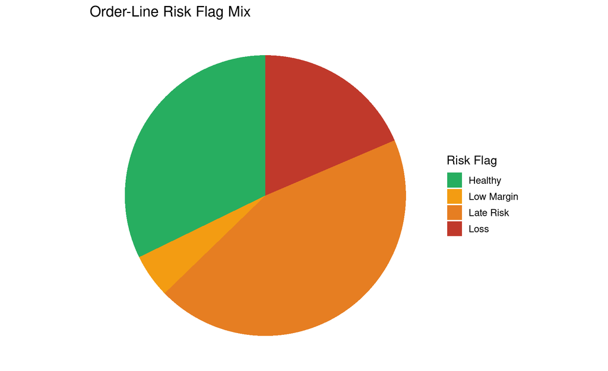

```r
ggplot(risk_mix, aes(x = "", y = Share, fill = factor(RiskFlag, levels = c("Healthy", "Low Margin", "Late Risk", "Loss")))) +
  geom_col(width = 1) +
  coord_polar("y") +
  scale_fill_manual(values = c("Healthy" = "#27AE60", "Low Margin" = "#F39C12",
                                "Late Risk" = "#E67E22", "Loss" = "#C0392B"), name = "Risk Flag") +
  labs(title = "Order-Line Risk Flag Mix") +
  theme_void(base_size = 13)
```

## Sales & Margin by Department Group

Mirrors the Excel dashboard’s department-group rollup table (`SUMIF` against the VLOOKUP-derived `DeptGroup` column).

```r
dept_rollup <- fin %>%
  group_by(DeptGroup) %>%
  summarise(Sales = sum(Sales, na.rm = TRUE), Profit = sum(OrderProfit, na.rm = TRUE), .groups = "drop") %>%
  mutate(Margin = Profit / Sales) %>%
  arrange(desc(Sales))

dept_rollup
```

| DeptGroup | Sales | Profit | Margin |
| --- | --- | --- | --- |
| Sporting Goods | 1033669.06 | 95078.26 | 0.09198134 |
| Apparel & Footwear | 618825.87 | 67941.84 | 0.10979153 |
| Technology | 151080.16 | 21432.64 | 0.14186270 |
| Outdoor & Recreation | 137301.55 | 15881.95 | 0.11567204 |
| Other Specialty | 44802.09 | 4423.10 | 0.09872530 |

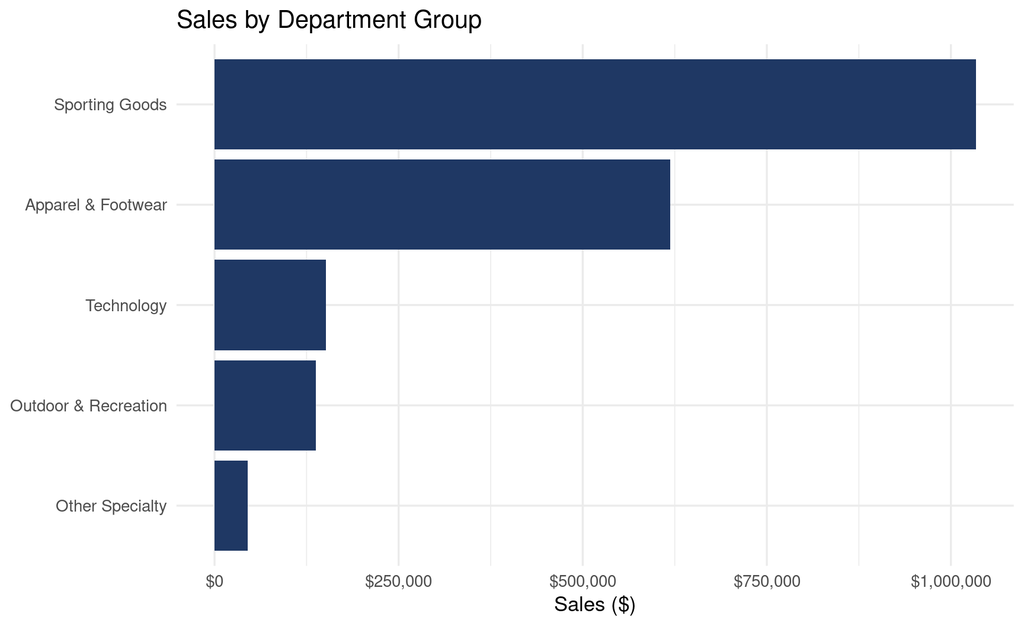

```r
ggplot(dept_rollup, aes(x = reorder(DeptGroup, Sales), y = Sales)) +
  geom_col(fill = "#1F3864") +
  coord_flip() +
  scale_y_continuous(labels = dollar) +
  labs(title = "Sales by Department Group", x = NULL, y = "Sales ($)") +
  theme_minimal(base_size = 13)
```

## Sales by Department Group × Order Status

Mirrors the native pivot table on the Excel “Profitability Dashboard” sheet (DeptGroup on rows, OrderStatus on columns, sum of Sales as the data field).

```r
pivot_tbl <- fin %>%
  count(DeptGroup, OrderStatus, wt = Sales, name = "Sales") %>%
  pivot_wider(names_from = OrderStatus, values_from = Sales, values_fill = 0)

pivot_tbl
```

| DeptGroup | CANCELED | CLOSED | COMPLETE | ON_HOLD | PAYMENT_REVIEW | PENDING | PENDING_PAYMENT | PROCESSING | SUSPECTED_FRAUD |
| --- | --- | --- | --- | --- | --- | --- | --- | --- | --- |
| Apparel & Footwear | 7816.97 | 65557.08 | 211758.95 | 35475.37 | 5149.39 | 72726.33 | 133742.00 | 70372.01 | 16227.76 |
| Other Specialty | 1603.63 | 5687.39 | 13897.44 | 1097.95 | 487.19 | 4550.80 | 10100.34 | 6413.36 | 963.99 |
| Outdoor & Recreation | 1755.38 | 16135.54 | 41135.60 | 6328.73 | 892.81 | 19673.19 | 27529.62 | 19470.05 | 4380.63 |
| Sporting Goods | 20291.11 | 105199.74 | 329167.37 | 52185.60 | 13460.32 | 125065.97 | 235151.47 | 128293.07 | 24854.40 |
| Technology | 3760.20 | 16591.40 | 47624.56 | 2457.80 | 704.92 | 13303.64 | 38496.72 | 24183.12 | 3957.80 |

## Fulfillment: Late Delivery by Market & Shipping Mode

Mirrors the Excel “Fulfillment Analysis” sheet’s two `COUNTIFS`/`AVERAGEIF` tables (late rate and avg shipping days, split by Market and by ShippingMode).

```r
by_market <- fin %>%
  group_by(Market) %>%
  summarise(Orders = n(), Late_Rate = mean(LateDeliveryRisk == 1),
            Avg_Days_Actual = mean(ShippingDaysActual, na.rm = TRUE),
            Avg_Days_Scheduled = mean(ShippingDaysScheduled, na.rm = TRUE), .groups = "drop") %>%
  arrange(desc(Late_Rate))

by_mode <- fin %>%
  group_by(ShippingMode) %>%
  summarise(Orders = n(), Late_Rate = mean(LateDeliveryRisk == 1),
            Avg_Days_Actual = mean(ShippingDaysActual, na.rm = TRUE),
            Avg_Days_Scheduled = mean(ShippingDaysScheduled, na.rm = TRUE), .groups = "drop") %>%
  arrange(desc(Late_Rate))

by_market
```

| Market | Orders | Late_Rate | Avg_Days_Actual | Avg_Days_Scheduled |
| --- | --- | --- | --- | --- |
| Europe | 3632 | 0.5539648 | 3.508811 | 2.919879 |
| Pacific Asia | 767 | 0.5449804 | 3.440678 | 2.857888 |
| LATAM | 4369 | 0.5376516 | 3.493935 | 2.949416 |
| Africa | 212 | 0.4386792 | 3.485849 | 3.169811 |
| USCA | 20 | 0.3500000 | 3.100000 | 2.600000 |

```r
by_mode
```

| ShippingMode | Orders | Late_Rate | Avg_Days_Actual | Avg_Days_Scheduled |
| --- | --- | --- | --- | --- |
| First Class | 1361 | 0.9493020 | 2.0000000 | 1 |
| Second Class | 1767 | 0.7611771 | 3.9926429 | 2 |
| Same Day | 494 | 0.4736842 | 0.5121457 | 0 |
| Standard Class | 5378 | 0.3733730 | 3.9827073 | 4 |

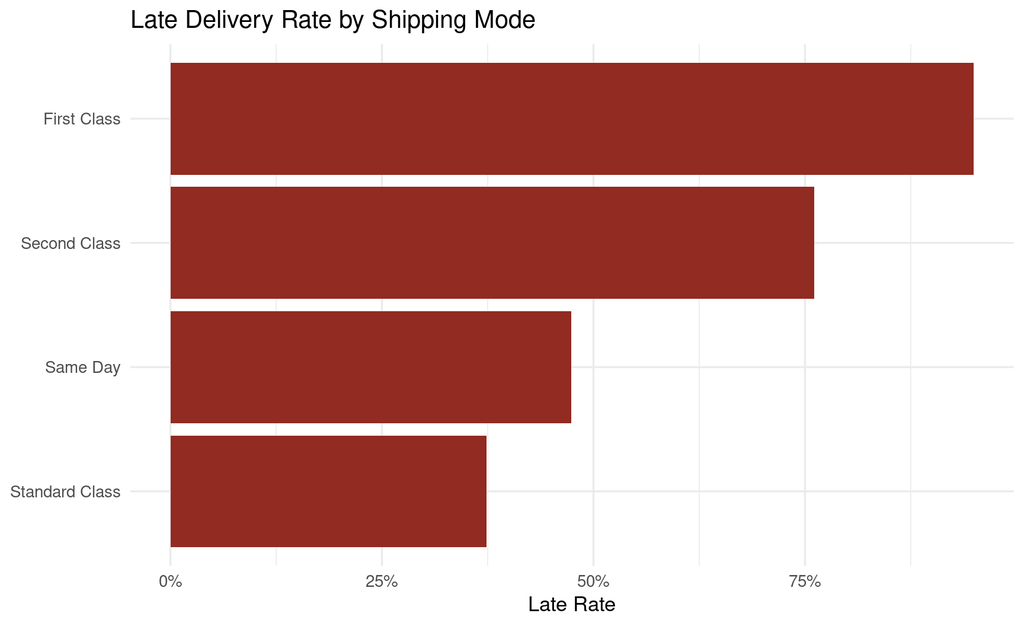

```r
ggplot(by_mode, aes(x = reorder(ShippingMode, Late_Rate), y = Late_Rate)) +
  geom_col(fill = "#922B21") +
  coord_flip() +
  scale_y_continuous(labels = percent) +
  labs(title = "Late Delivery Rate by Shipping Mode", x = NULL, y = "Late Rate") +
  theme_minimal(base_size = 13)
```

*Data source: a retail supply-chain order/shipment dataset (DataCo-style schema), in the same spirit as the public “DataCo Supply Chain” Kaggle dataset.*